# Comparison of Extraction Methods (peptides)

all tissues (cells, fresh-frozen, FFPE, plasma, serum)

Thomas Naake[^1]

In the following section check if there is a relation between physico-chemical properties and the observed differences between the extraction methods.

Use here the peptide datasets.

# 1 Load the data set

```r
setwd("~/GitLab/20211202_extraction_method/")

## load cells data set
cells <- maxQuant("peptides_cells.txt", intensity = "LFQ", type = "txt")
cells <- assay(cells) %>%
    transformAssay(method = "log") %>%
    MatrixQCvis:::updateSE(cells, assay = .)

## load fresh-frozen data set
ff <- maxQuant("peptides_freshfrozen.txt", intensity = "LFQ", type = "txt")
ff <- assay(ff) %>%
    transformAssay(method = "log") %>%
    MatrixQCvis:::updateSE(ff, assay = .)

## load FFPE data set
ffpe <- maxQuant("peptides_FFPE.txt", intensity = "LFQ", type = "txt")
ffpe <- assay(ffpe) %>%
    transformAssay(method = "log") %>%
    MatrixQCvis:::updateSE(ffpe, assay = .)

## load Serum-plasma
plasma_serum <- maxQuant("peptides_blood.txt", intensity = "LFQ", type = "txt")
plasma_serum <- assay(plasma_serum) %>%
    transformAssay(method = "log") %>%
    MatrixQCvis:::updateSE(plasma_serum, assay = .)
```

## 1.1 Update the colData and rowData slots with the annotations

```r
column_keep <- c("Sample_IDs", "condition", "LFQ")

## load the annotation
annot <- openxlsx::read.xlsx("proteinGroups_overview.xlsx",
    sheet = "annotation", startRow = 2)
annot <- annot[, column_keep]
annot <- annot[!annot$condition %in% "ignore", ]
annot <- annot[!is.na(annot$condition), ]

## truncate the annotation for Cells
annot_cells <- annot[grep(annot$condition, pattern = "Cells"), ]

## truncate the annotation for Fresh-frozen
annot_ff <- annot[grep(annot$Sample_IDs, pattern = "powder_tissue_AFA_|_T"), ]

## truncate the annotation for FFPE
annot_ffpe <- annot[grep(annot$Sample_IDs, pattern = "_FFPE"), ]

## truncate the annotation for Plasma and Serum
annot_plasma <- annot[grep(annot$condition, pattern = "Plasma"), ]
annot_serum <- annot[grep(annot$condition, pattern = "Serum"), ]
```

Load the protein FASTA files and cut the sequence names.

## 1.2 Update the colData and rowData slots with the annotations

Write the annotations and the sequences to the `colData` and `rowData` slots.

```r
## cells
annot_cells$Sample_IDs <- make.names(annot_cells$Sample_IDs)
cells <- cells[, annot_cells$Sample_IDs]
cD <- colData(cells) %>% as.data.frame()
cells@colData <- left_join(cD, annot_cells, by = c("name" = "Sample_IDs")) %>%
  DataFrame()

## fresh-frozen
annot_ff$Sample_IDs <- make.names(annot_ff$Sample_IDs)
ff <- ff[, annot_ff$Sample_IDs]
cD <- colData(ff) %>% as.data.frame()
ff@colData <- left_join(cD, annot_ff, by = c("name" = "Sample_IDs")) %>%
  DataFrame()

## FFPE
annot_ffpe$Sample_IDs <- make.names(annot_ffpe$Sample_IDs)
ffpe <- ffpe[, annot_ffpe$Sample_IDs]
cD <- colData(ffpe) %>% as.data.frame()
ffpe@colData <- left_join(cD, annot_ffpe, by = c("name" = "Sample_IDs")) %>%
  DataFrame()

## Plasma
annot_plasma$Sample_IDs <- make.names(annot_plasma$Sample_IDs)
annot_plasma$Sample_IDs <- gsub(annot_plasma$Sample_IDs, pattern = "[.]",
    replacement = "_")
colnames(plasma_serum) <- gsub(colnames(plasma_serum), pattern = "[.]",
    replacement = "_")
plasma_serum$name <- colnames(plasma_serum)
plasma <- plasma_serum[, annot_plasma$Sample_IDs]
cD <- colData(plasma) %>% as.data.frame()
plasma@colData <- left_join(cD, annot_plasma, by = c("name" = "Sample_IDs")) %>%
  DataFrame()

## Serum
annot_serum$Sample_IDs <- make.names(annot_serum$Sample_IDs)
annot_serum$Sample_IDs <- gsub(annot_serum$Sample_IDs, pattern = "[.]",
    replacement = "_")
serum <- plasma_serum[, annot_serum$Sample_IDs]
cD <- colData(serum) %>% as.data.frame()
serum@colData <- left_join(cD, annot_serum, by = c("name" = "Sample_IDs")) %>%
  DataFrame()

## write the SummarizedExperiment objects to _old to retrieve them later
cells_old <- cells; ff_old <- ff; ffpe_old <- ffpe; plasma_old <- plasma; serum_old <- serum
```

# 2 Differential expression analysis

For the differential expression analysis use in all cases the following scheme:

- create the model matrix,
- fit a linear model for each protein taking into account the model matrix using `lmFit` and method `"ls"`,
- create the contrasts between two levels as specified in each section,
- compute contrasts from linear model fit; given the linear model fit to the data, compute estimated coefficients and standard errors for a given set of contrasts (using `contrasts.fit`)
- run Empirical Bayes Statistics for differential expressino; Given a linear model fit from `lmFit`, compute moderated t-statistics, moderated F-statistic, and log-odds of differential expression by empirical Bayes moderation of the standard errors towards a global value (using `eBayes`)

```r
## set parameters for differential expression (num only for display)
num <- 500
p_val <- 1
adj <- "BH"
```

The `*_TwoPhase_AFA` refers to `*_MTBE_SP3`, while the `*_AFA` refers to `*_autoSP3`.

# 3 Cells

contrasts:

- Cells_AFA - Cells_TwoPhase_AFA

## 3.1 Cells: Overlap, uniqueness of features

The plot shows the interaction of sets between different variables depending on their presence. The dots in the UpSet plot specify if the criteria for presence are fulfilled: Presence is defined by a feature being measured in at least one sample of a set.

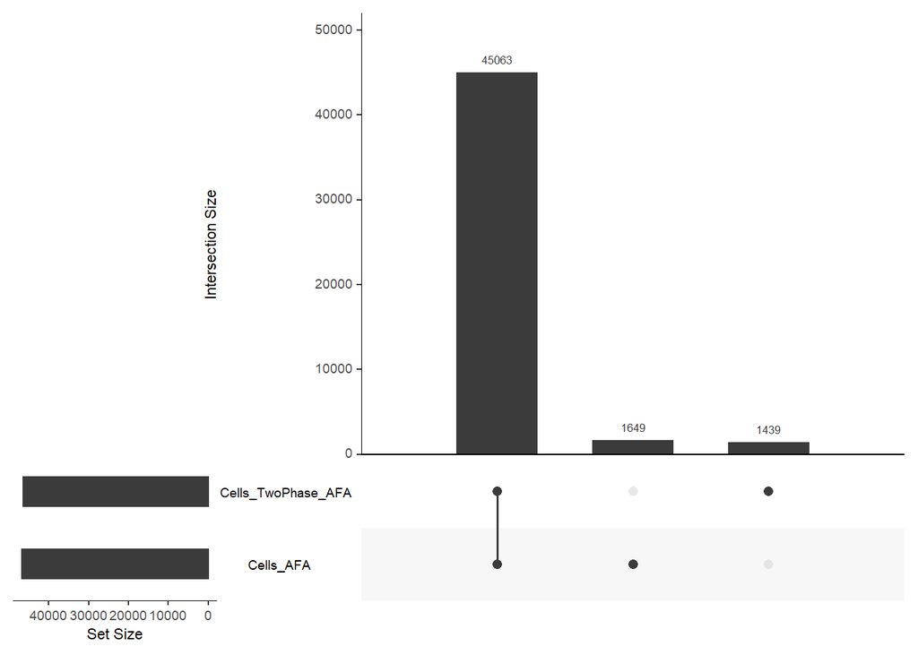

Only continue with the shared features in the following analyses.

## 3.2 Cells: CV

```
## [1] "mean: Cells_AFA"
```

```
## [1] 3.828534
```

```
## [1] "mean: Cells_TwoPhase_AFA"
```

```
## [1] 4.019095
```

```
##
##  Wilcoxon signed rank test with continuity correction
##
## data:  cv_a and cv_b
## V = 340815671, p-value = 2.687e-06
## alternative hypothesis: true location shift is not equal to 0
```

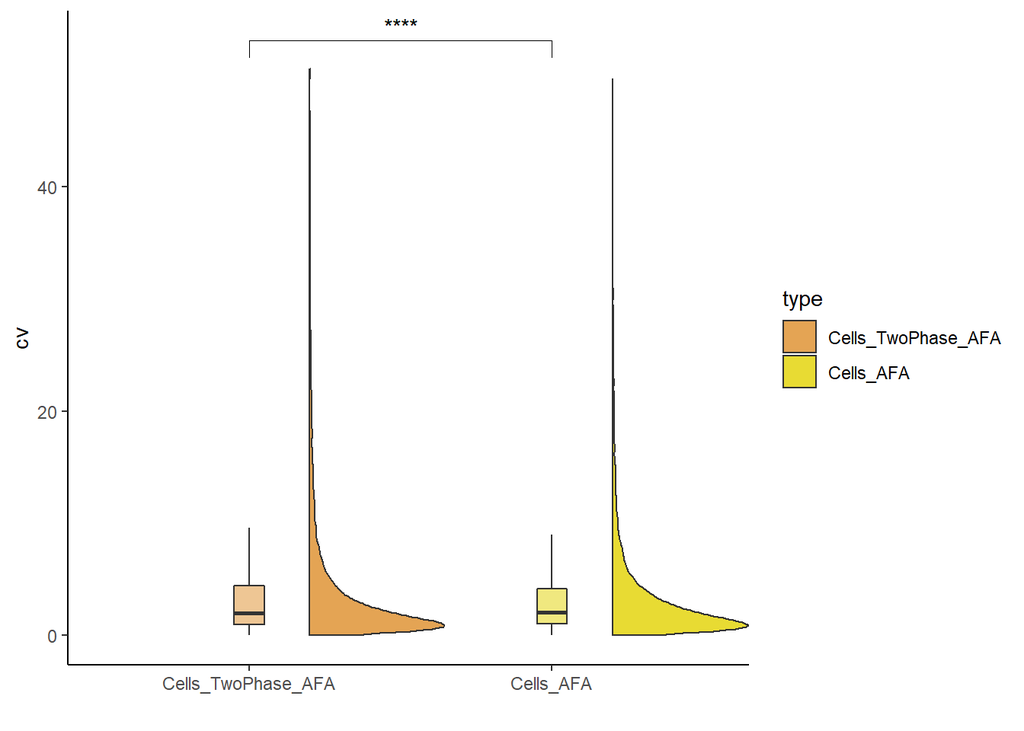

The TwoPhase method shows higher CV compared to the traditional AFA method.

## 3.3 Cells: Differential expression analysis

|  | logFC | AveExpr | t | P.Value | adj.P.Val | B |
| --- | --- | --- | --- | --- | --- | --- |
| AAAAAAAAAAAAAAAGAGAGAK | -0.1595786861 | 9.235143 | -0.560384958 | 5.974924e-01 | 0.9998398 | -6.2093077 |
| AAAAAAAAAAGAAGGR | -0.1444856715 | 12.071654 | -0.488319278 | 6.443560e-01 | 0.9998398 | -6.2506300 |
| AAAAAAAAAVSR | 0.1297556509 | 9.323334 | 0.343179588 | 7.443188e-01 | 0.9998398 | -6.3178024 |
| AAAAAAAGDSDSWDADAFSVEDPVR | -1.2108431767 | 8.717146 | -3.939481293 | 2.254396e-02 | 0.7474633 | -2.7470410 |
| AAAAAAAGDSDSWDADAFSVEDPVRK | 0.2414373303 | 11.029383 | 0.628785967 | 5.549237e-01 | 0.9998398 | -6.1654525 |
| AAAAAAALQAK | 0.1632827559 | 13.143378 | 0.421037779 | 6.898329e-01 | 0.9998398 | -6.2844990 |
| AAAAAAGAASGLPGPVAQGLK | -0.0959606038 | 12.695510 | -0.857200966 | 4.274380e-01 | 0.9998398 | -5.9890006 |
| AAAAAAGAGPEMVR | -0.0698223912 | 12.945372 | -0.338007330 | 7.480025e-01 | 0.9998398 | -6.3197859 |
| AAAAAATAAAAASIR | 0.2341737604 | 10.149592 | 0.465591320 | 6.595399e-01 | 0.9998398 | -6.2625885 |
| AAAAAEQQQFYLLLGNLLSPDNVVR | -0.0509310999 | 10.818696 | -0.143003471 | 8.914299e-01 | 0.9998398 | -6.3730728 |

[output cut: 490 more lines]

## 3.4 Cells: Association to physico-chemical parameters

Take the t-values and plot against the GRAVY-Score and Isoelectric point (for shared features).

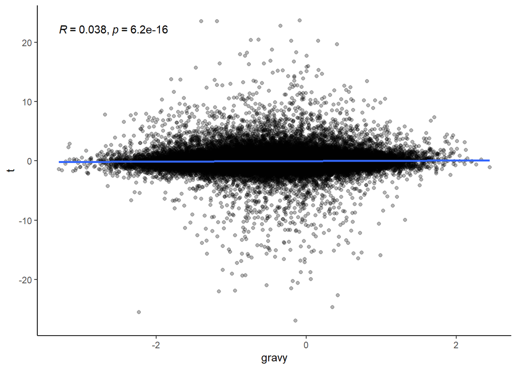

```
##
##  Spearman's rank correlation rho
##
## data:  gravy and t
## S = 1.4671e+13, p-value = 6.153e-16
## alternative hypothesis: true rho is not equal to 0
## sample estimates:
##        rho
## 0.03807949
```

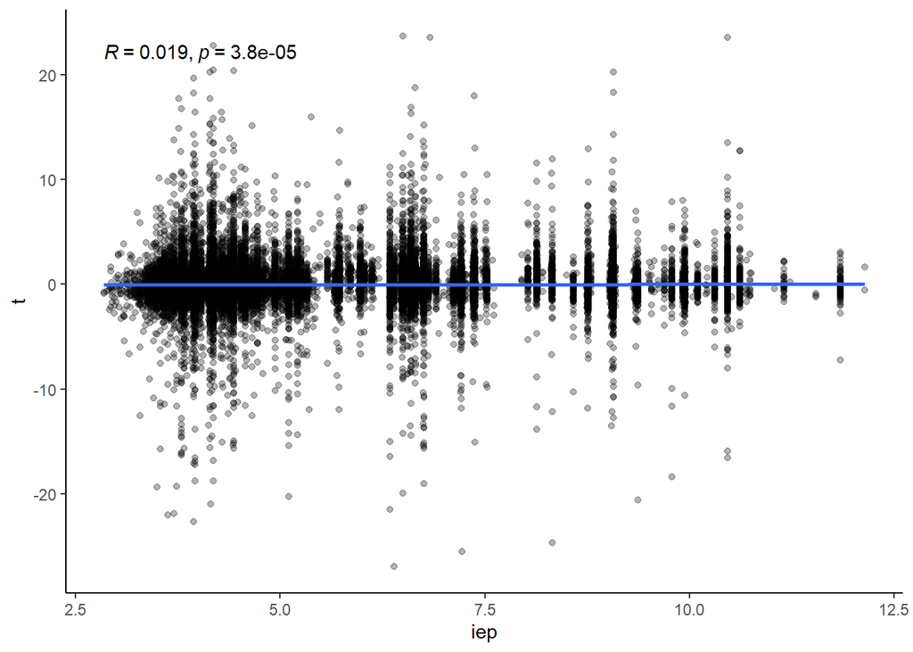

```
##
##  Spearman's rank correlation rho
##
## data:  iep and t
## S = 1.4955e+13, p-value = 3.762e-05
## alternative hypothesis: true rho is not equal to 0
## sample estimates:
##        rho
## 0.01941454
```

Create violin plots for shared/unique features.

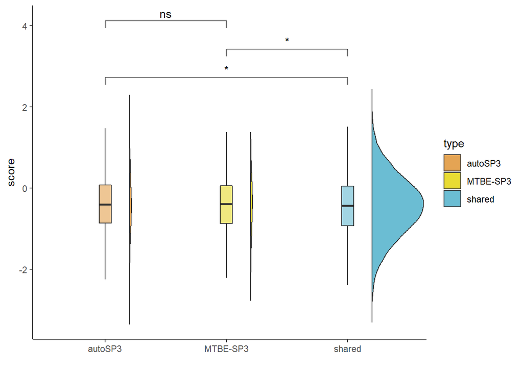

```r
## gravy
feat <- read.table(file = "peptides_unique_features_cells_Cells_AFA.txt",
    header = TRUE)
gravy_other <- lapply(feat[, 1], function(aa) calculateGravyScore(aa))
feat <- read.table(file = "peptides_unique_features_cells_Cells_TwoPhase_AFA.txt",
    header = TRUE)
gravy_tp <- lapply(feat[, 1], function(aa) calculateGravyScore(aa))

## create df
df <- data.frame(rbind(
    cbind(unlist(gravy), "shared"),
    cbind(unlist(gravy_other), "autoSP3"),
    cbind(unlist(gravy_tp), "MTBE-SP3")))
colnames(df) <- c("score", "type")
df$score <- as.numeric(df$score)
df$type <- factor(df$type, levels = c("autoSP3", "MTBE-SP3", "shared"))
comparisons <- list( c("autoSP3", "shared"), c("MTBE-SP3", "shared"),
    c("autoSP3", "MTBE-SP3"))

plot_violin_barplot(df = df, x = "type", y = "score", fill = "type",
    comparisons = comparisons, file = "peptide_violin_gravy_cells.pdf",
    method = "wilcox.test", paired = FALSE)
```

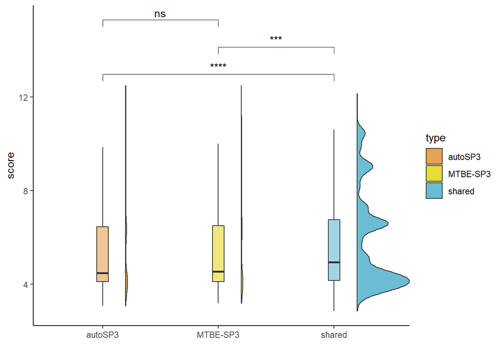

```r
## iep
feat <- read.table(file = "peptides_unique_features_cells_Cells_AFA.txt",
    header = TRUE)
iep_other <- lapply(feat[, 1], function(aa) calculateIsoelectricPoint(aa))
feat <- read.table(file = "peptides_unique_features_cells_Cells_TwoPhase_AFA.txt",
    header = TRUE)
iep_tp <- lapply(feat[, 1], function(aa) calculateIsoelectricPoint(aa))

## create df
df <- data.frame(rbind(
    cbind(unlist(iep), "shared"),
    cbind(unlist(iep_other), "autoSP3"),
    cbind(unlist(iep_tp), "MTBE-SP3")))
colnames(df) <- c("score", "type")
df$score <- as.numeric(df$score)
df$type <- factor(df$type, levels = c("autoSP3", "MTBE-SP3", "shared"))
comparisons <- list( c("autoSP3", "shared"), c("MTBE-SP3", "shared"),
    c("autoSP3", "MTBE-SP3"))

plot_violin_barplot(df = df, x = "type", y = "score", fill = "type",
    comparisons = comparisons, file = "peptide_violin_iep_cells.pdf",
    method = "wilcox.test", paired = FALSE)
```

# 4 Fresh-frozen

contrasts:

- powder_AFA - powder_TwoPhase_AFA (contrast 1)
- Tissue_bulk_AFA - powder_Two_Phase_AFA (contrast 2)

Upset plot for all condition types.

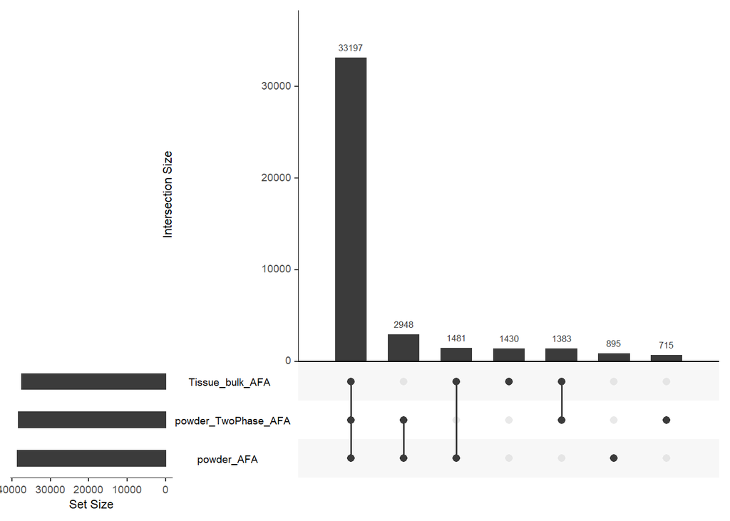

## 4.1 Fresh-frozen: Overlap, uniqueness of features (contrast 1)

The plot shows the interaction of sets between different variables depending on their presence. The dots in the UpSet plot specify if the criteria for presence are fulfilled: Presence is defined by a feature being measured in at least one sample of a set.

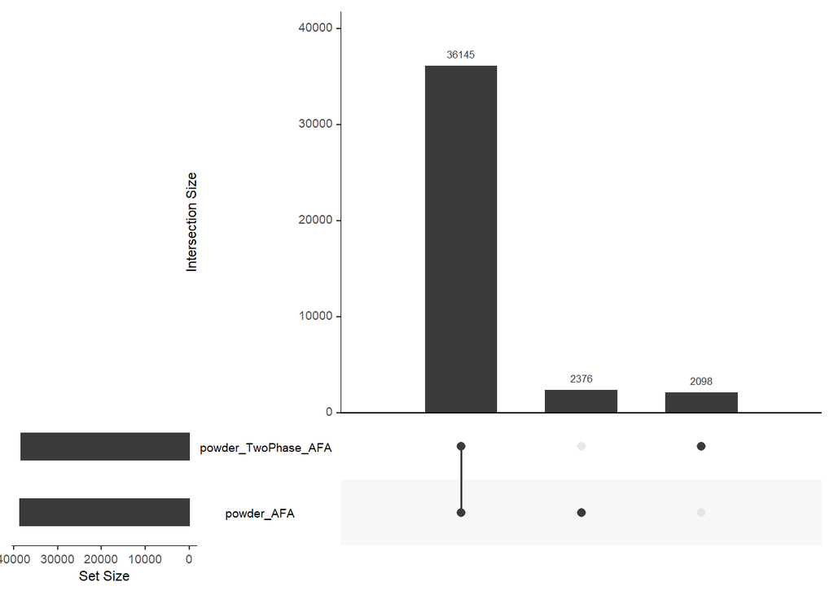

Only continue with the shared features in the following analyses.

## 4.2 Fresh-frozen: CV (contrast 1)

```
## [1] "mean: powder_AFA"
```

```
## [1] 3.322156
```

```
## [1] "mean: powder_TwoPhase_AFA"
```

```
## [1] 3.867028
```

```
##
##  Wilcoxon signed rank test with continuity correction
##
## data:  cv_a and cv_b
## V = 164629970, p-value < 2.2e-16
## alternative hypothesis: true location shift is not equal to 0
```

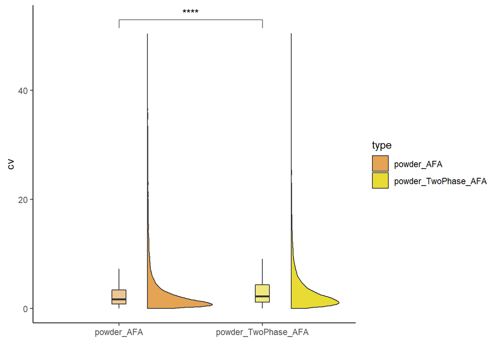

## 4.3 Fresh-frozen: Differential expression analysis (contrast 1)

```
## [1] "## contrast: powder_AFA - powder_TwoPhase_AFA"
```

|  | logFC | AveExpr | t | P.Value | adj.P.Val | B |
| --- | --- | --- | --- | --- | --- | --- |
| AAAAAAAAAAGAAGGR | -2.521998282 | 9.306088 | -4.433064128 | 0.0076855042 | 0.23008418 | -1.9315617 |
| AAAAAAAAAAGDSDSWDADTFSMEDPVRK | -3.621729583 | 10.175107 | -7.532371594 | 0.0021468921 | 0.16821244 | -0.8385389 |
| AAAAAAGAASGLPGPVAQGLK | 0.112361527 | 10.520130 | 0.233827892 | 0.8211779475 | 0.93818700 | -6.4442873 |
| AAAAAAGPEMVR | -0.892401711 | 9.557685 | -1.944121798 | 0.1285474082 | 0.48359139 | -4.7032320 |
| AAAAAASHLNLDALR | -0.058791073 | 9.189020 | -0.307188009 | 0.7667939368 | 0.91534731 | -6.4226174 |
| AAAAAGPASSQR | -0.329655864 | 10.608288 | -2.069930787 | 0.0733700733 | 0.41457392 | -4.6049961 |
| AAAAAGPGAWAAQEK | 0.582124537 | 9.590920 | 3.757187241 | 0.0058992891 | 0.21365712 | -2.1185993 |
| AAAADGEPLHNEEER | -0.342215329 | 10.306843 | -2.486062041 | 0.0386741201 | 0.34425305 | -3.9895761 |
| AAAAGALAPGPLPDLAAR | -0.078027847 | 11.930594 | -0.390891169 | 0.7064055941 | 0.88986966 | -6.3909177 |
| AAAAGAVVASAASGPAEGK | -1.255105129 | 9.367346 | -4.058591299 | 0.0052040146 | 0.21063730 | -1.8430436 |

[output cut: 490 more lines]

## 4.4 Fresh-frozen: Association to physico-chemical parameters (contrast 1)

Take the t-values and plot against the GRAVY-Score and Isoelectric point (for shared features).

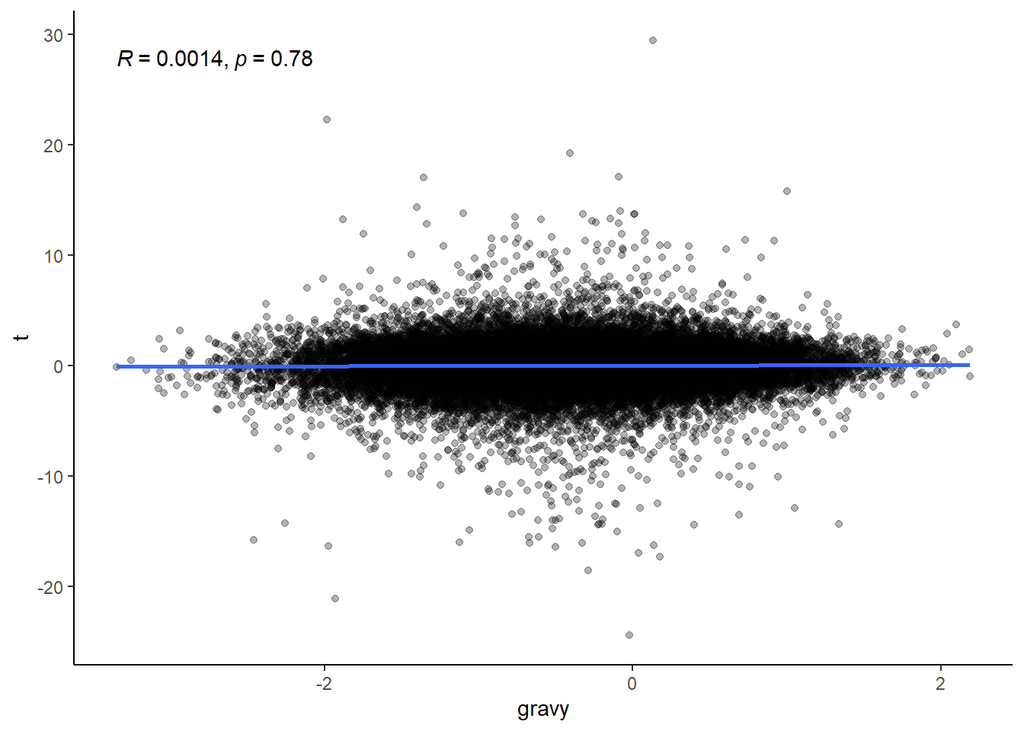

```
##
##  Spearman's rank correlation rho
##
## data:  gravy and t
## S = 7.859e+12, p-value = 0.7844
## alternative hypothesis: true rho is not equal to 0
## sample estimates:
##         rho
## 0.001439001
```

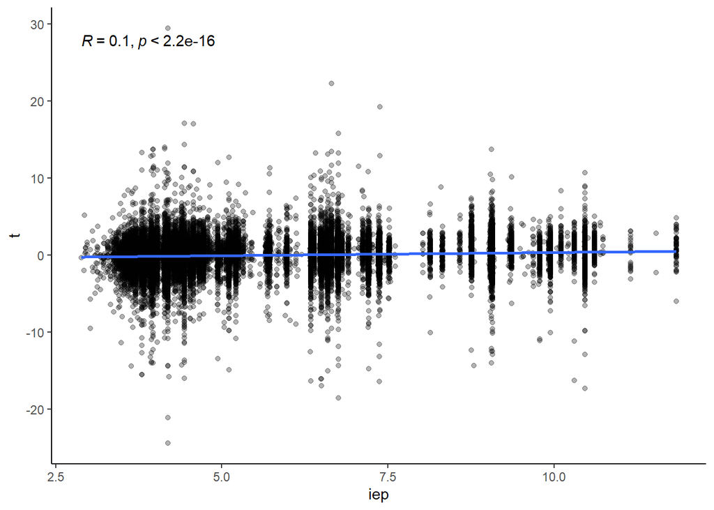

```
##
##  Spearman's rank correlation rho
##
## data:  iep and t
## S = 7.0548e+12, p-value < 2.2e-16
## alternative hypothesis: true rho is not equal to 0
## sample estimates:
##       rho
## 0.1036177
```

Create violin plots for shared/unique features.

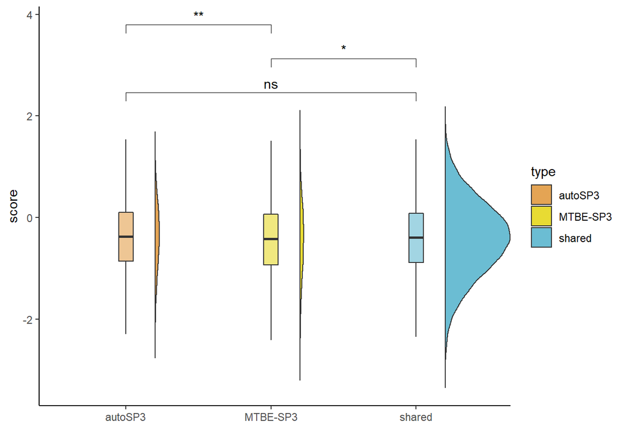

```r
## gravy
feat <- read.table(file = "peptides_unique_features_ff_contrast1_powder.txt",
    header = TRUE)
gravy_other <- lapply(feat[, 1], function(aa) calculateGravyScore(aa))
feat <- read.table(file = "peptides_unique_features_ff_contrast1_powder_TwoPhase.txt",
    header = TRUE)
gravy_tp <- lapply(feat[, 1], function(aa) calculateGravyScore(aa))

## create df
df <- data.frame(rbind(
    cbind(unlist(gravy), "shared"),
    cbind(unlist(gravy_other), "autoSP3"),
    cbind(unlist(gravy_tp), "MTBE-SP3")))
colnames(df) <- c("score", "type")
df$score <- as.numeric(df$score)
df$type <- factor(df$type, levels = c("autoSP3", "MTBE-SP3", "shared"))
comparisons <- list( c("autoSP3", "shared"), c("MTBE-SP3", "shared"),
    c("autoSP3", "MTBE-SP3"))

plot_violin_barplot(df = df, x = "type", y = "score", fill = "type",
    comparisons = comparisons, file = "peptide_violin_gravy_freshfrozen_1.pdf",
    method = "wilcox.test", paired = FALSE)
```

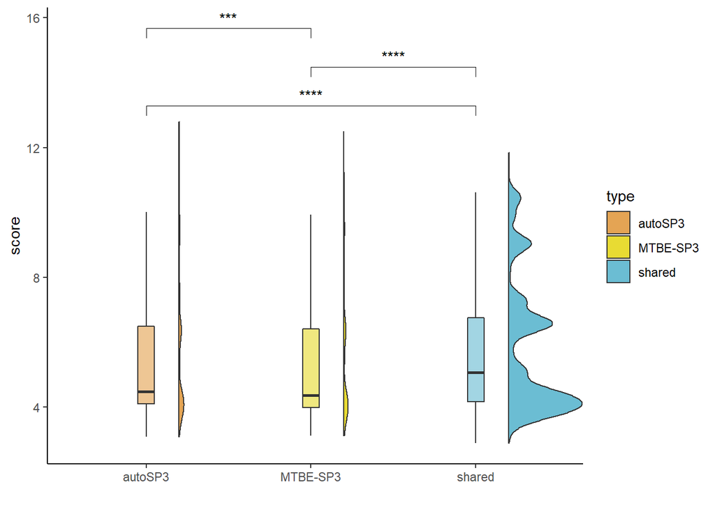

```r
## iep
feat <- read.table(file = "peptides_unique_features_ff_contrast1_powder.txt",
    header = TRUE)
iep_other <- lapply(feat[, 1], function(aa) calculateIsoelectricPoint(aa))
feat <- read.table(file = "peptides_unique_features_ff_contrast1_powder_TwoPhase.txt",
    header = TRUE)
iep_tp <- lapply(feat[, 1], function(aa) calculateIsoelectricPoint(aa))

## create df
df <- data.frame(rbind(
    cbind(unlist(iep), "shared"),
    cbind(unlist(iep_other), "autoSP3"),
    cbind(unlist(iep_tp), "MTBE-SP3")))
colnames(df) <- c("score", "type")
df$score <- as.numeric(df$score)
df$type <- factor(df$type, levels = c("autoSP3", "MTBE-SP3", "shared"))
comparisons <- list( c("autoSP3", "shared"), c("MTBE-SP3", "shared"),
    c("autoSP3", "MTBE-SP3"))

plot_violin_barplot(df = df, x = "type", y = "score", fill = "type",
    comparisons = comparisons, file = "peptide_violin_iep_freshfrozen_1.pdf",
    method = "wilcox.test", paired = FALSE)
```

## 4.5 Fresh-frozen: Overlap, uniqueness of features (contrast 2)

The plot shows the interaction of sets between different variables depending on their presence. The dots in the UpSet plot specify if the criteria for presence are fulfilled: Presence is defined by a feature being measured in at least one sample of a set.

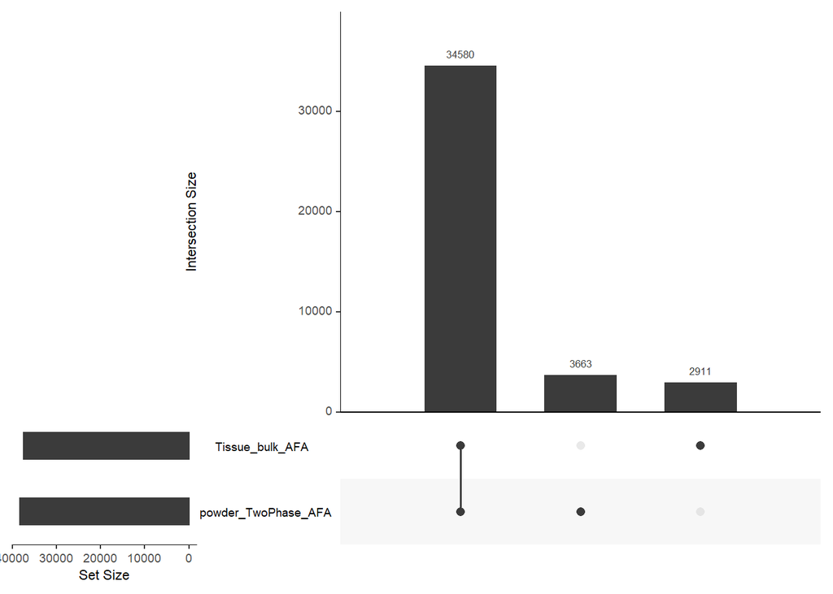

Only continue with the shared features in the following analyses.

## 4.6 Fresh-frozen: CV (contrast 2)

```
## [1] "mean: Tissue_bulk_AFA"
```

```
## [1] 4.655814
```

```
## [1] "mean: powder_TwoPhase_AFA"
```

```
## [1] 3.773535
```

```
##
##  Wilcoxon signed rank test with continuity correction
##
## data:  cv_a and cv_b
## V = 223327714, p-value < 2.2e-16
## alternative hypothesis: true location shift is not equal to 0
```

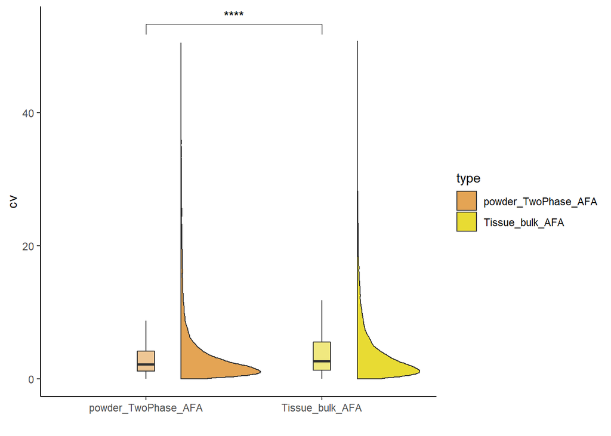

## 4.7 Fresh-frozen: Differential expression analysis (contrast 2)

```
## [1] "## contrast: Tissue_bulk_AFA - powder_TwoPhase_AFA"
```

|  | logFC | AveExpr | t | P.Value | adj.P.Val | B |
| --- | --- | --- | --- | --- | --- | --- |
| AAAAAAAAAAGAAGGR | -1.9266195488 | 9.306088 | -4.283661857 | 8.794838e-03 | 0.063544821 | -2.36314532 |
| AAAAAAAAAAGDSDSWDADTFSMEDPVRK | -0.0060562154 | 10.175107 | -0.015426331 | 9.884779e-01 | 0.992611972 | -6.67993778 |
| AAAAAAGAASGLPGPVAQGLK | -0.3041443784 | 10.520130 | -0.632934073 | 5.449990e-01 | 0.692437330 | -6.66207589 |
| AAAAAAPGGGGGEPR | -1.0087998507 | 10.406000 | -1.864443095 | 1.136761e-01 | 0.259363895 | -5.30548757 |
| AAAAAASHLNLDALR | 0.2240688490 | 9.189020 | 1.170777475 | 2.764337e-01 | 0.449162593 | -6.17574167 |
| AAAAAGPASSQR | -0.8577371641 | 10.608288 | -5.385787900 | 7.313739e-04 | 0.021153364 | -0.23696938 |
| AAAAAGPGAWAAQEK | 0.5211871797 | 9.590920 | 3.363881262 | 1.034657e-02 | 0.068751836 | -3.00773841 |
| AAAADGEPLHNEEER | 0.0835847759 | 10.306843 | 0.607211078 | 5.610788e-01 | 0.705115422 | -6.67904646 |
| AAAAGALAPGPLPDLAAR | -0.0200805834 | 11.930594 | -0.100596429 | 9.224250e-01 | 0.953586122 | -6.87458656 |
| AAAAGAVVASAASGPAEGK | 0.1218300838 | 9.367346 | 0.440458266 | 6.733680e-01 | 0.788530042 | -6.77158438 |

[output cut: 490 more lines]

## 4.8 Fresh-frozen: Association to physico-chemical parameters (contrast 2)

Take the t-values and plot against the GRAVY-Score and Isoelectric point (for shared features).

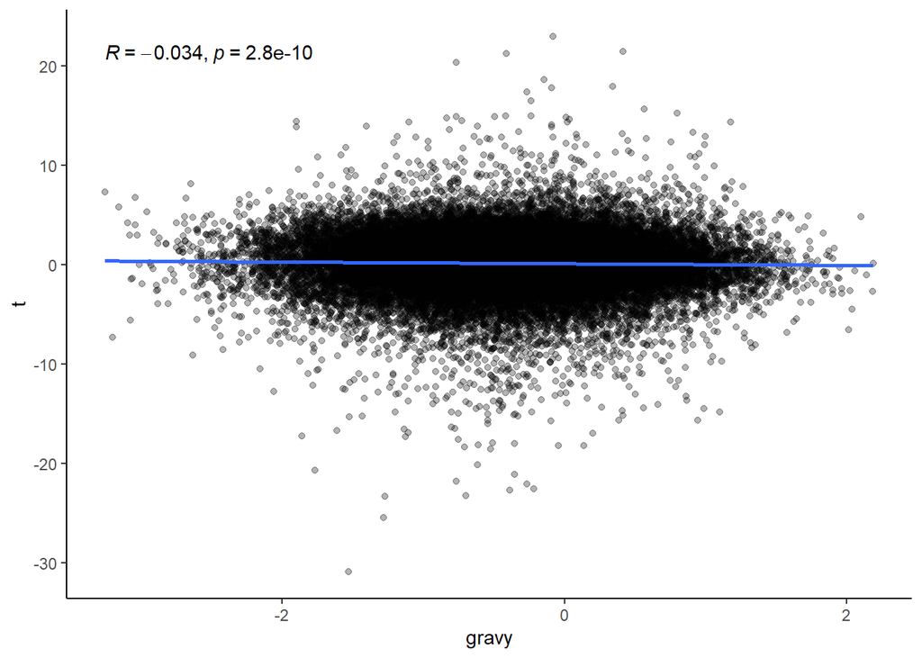

```
##
##  Spearman's rank correlation rho
##
## data:  gravy and t
## S = 7.1255e+12, p-value = 2.775e-10
## alternative hypothesis: true rho is not equal to 0
## sample estimates:
##        rho
## -0.0339287
```

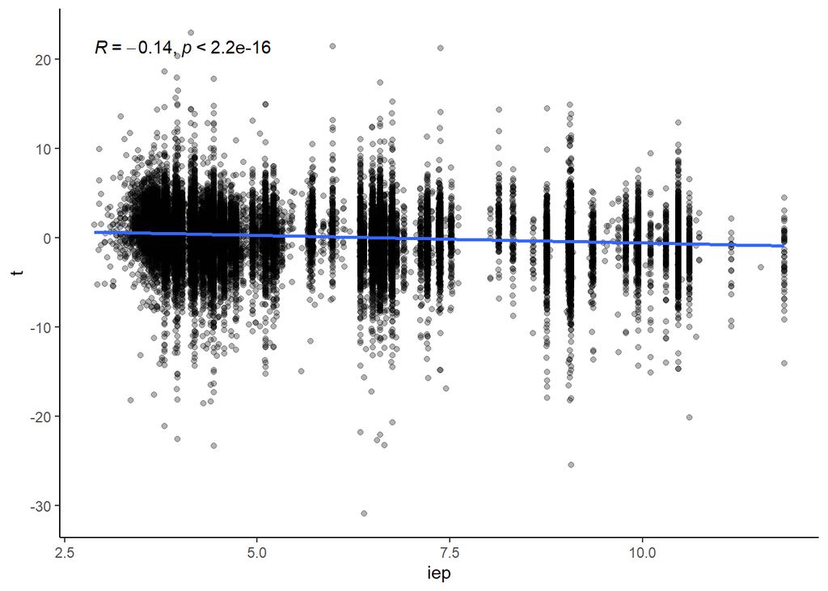

```
##
##  Spearman's rank correlation rho
##
## data:  iep and t
## S = 7.876e+12, p-value < 2.2e-16
## alternative hypothesis: true rho is not equal to 0
## sample estimates:
##        rho
## -0.1428304
```

Create violin plots for shared/unique features.

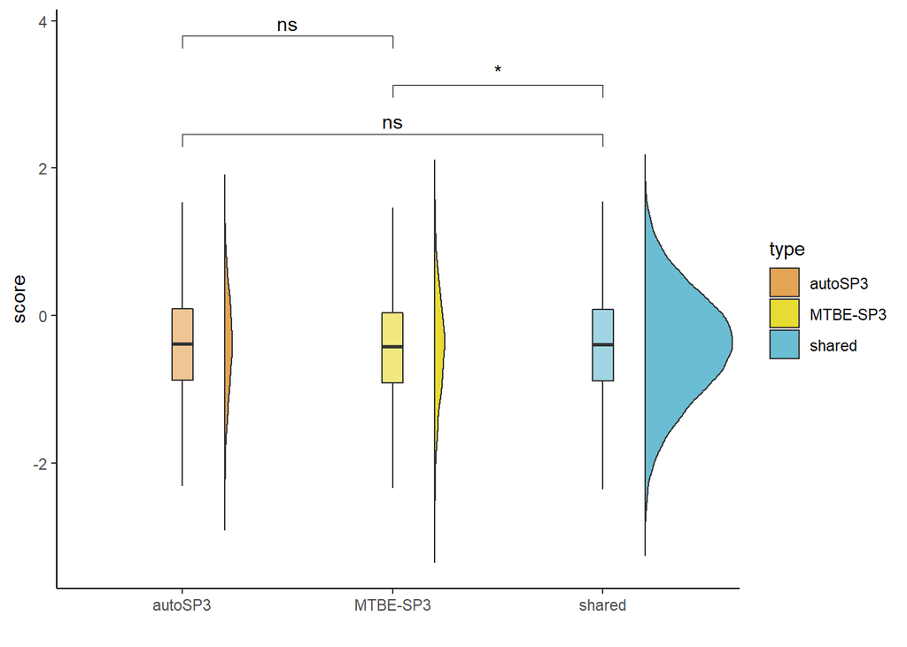

```r
## gravy
feat <- read.table(file = "peptides_unique_features_ff_contrast2_Tissue_bulk.txt",
    header = TRUE)
gravy_other <- lapply(feat[, 1], function(aa) calculateGravyScore(aa))
feat <- read.table(file = "peptides_unique_features_ff_contrast2_powder_TwoPhase.txt",
    header = TRUE)
gravy_tp <- lapply(feat[, 1], function(aa) calculateGravyScore(aa))

## create df
df <- data.frame(rbind(
    cbind(unlist(gravy), "shared"),
    cbind(unlist(gravy_other), "autoSP3"),
    cbind(unlist(gravy_tp), "MTBE-SP3")))
colnames(df) <- c("score", "type")
df$score <- as.numeric(df$score)
df$type <- factor(df$type, levels = c("autoSP3", "MTBE-SP3", "shared"))
comparisons <- list( c("autoSP3", "shared"), c("MTBE-SP3", "shared"),
    c("autoSP3", "MTBE-SP3"))

plot_violin_barplot(df = df, x = "type", y = "score", fill = "type",
    comparisons = comparisons, file = "peptide_violin_gravy_freshfrozen_2.pdf",
    method = "wilcox.test", paired = FALSE)
```

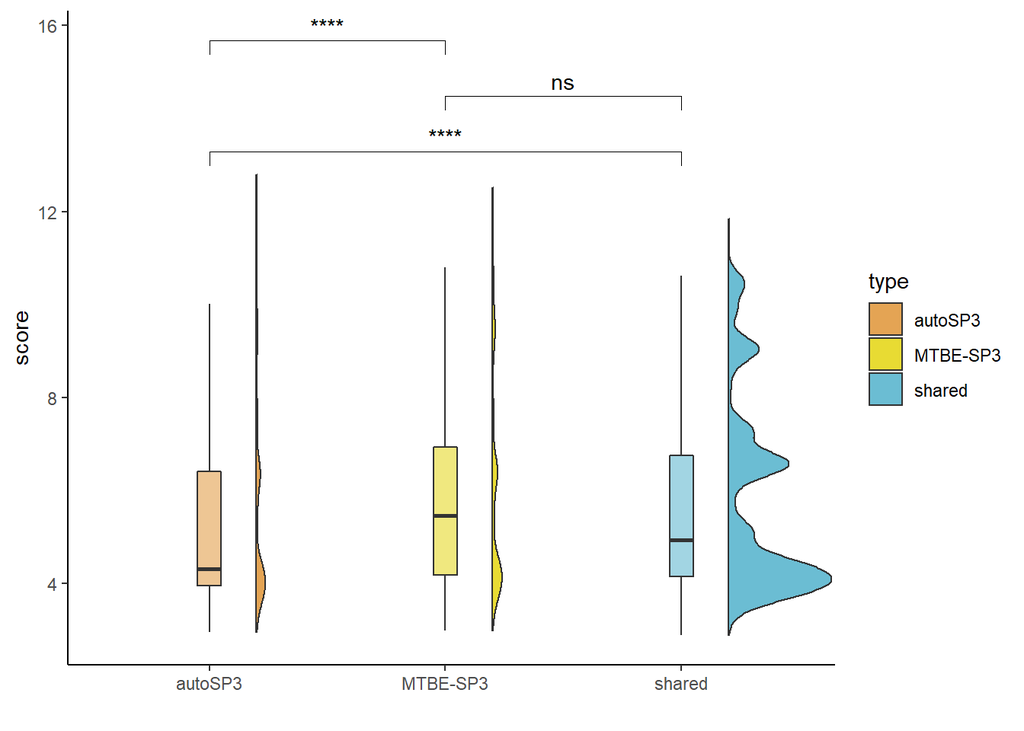

```r
## iep
feat <- read.table(file = "peptides_unique_features_ff_contrast2_Tissue_bulk.txt",
    header = TRUE)
iep_other <- lapply(feat[, 1], function(aa) calculateIsoelectricPoint(aa))
feat <- read.table(file = "peptides_unique_features_ff_contrast2_powder_TwoPhase.txt",
    header = TRUE)
iep_tp <- lapply(feat[, 1], function(aa) calculateIsoelectricPoint(aa))

## create df
df <- data.frame(rbind(
    cbind(unlist(iep), "shared"),
    cbind(unlist(iep_other), "autoSP3"),
    cbind(unlist(iep_tp), "MTBE-SP3")))
colnames(df) <- c("score", "type")
df$score <- as.numeric(df$score)
df$type <- factor(df$type, levels = c("autoSP3", "MTBE-SP3", "shared"))
comparisons <- list( c("autoSP3", "shared"), c("MTBE-SP3", "shared"),
    c("autoSP3", "MTBE-SP3"))

plot_violin_barplot(df = df, x = "type", y = "score", fill = "type",
    comparisons = comparisons, file = "peptide_violin_iep_freshfrozen_2.pdf",
    method = "wilcox.test", paired = FALSE)
```

# 5 FFPE

contrasts:

- powder_AFA - powder_TwoPhase_AFA (contrast 1)
- FFPE_AFA - powder_TwoPhase_AFA (contrast 2)

Upset plot for all condition types.

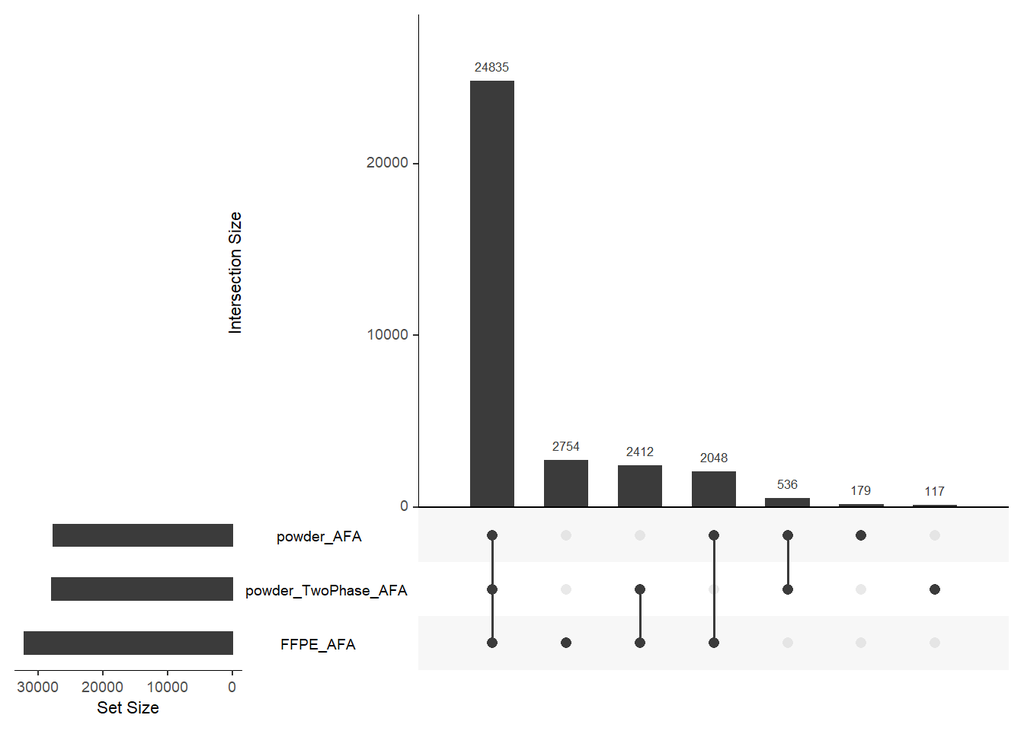

## 5.1 FFPE: Overlap, uniqueness of features (contrast 1)

The plot shows the interaction of sets between different variables depending on their presence. The dots in the UpSet plot specify if the criteria for presence are fulfilled: Presence is defined by a feature being measured in at least one sample of a set.

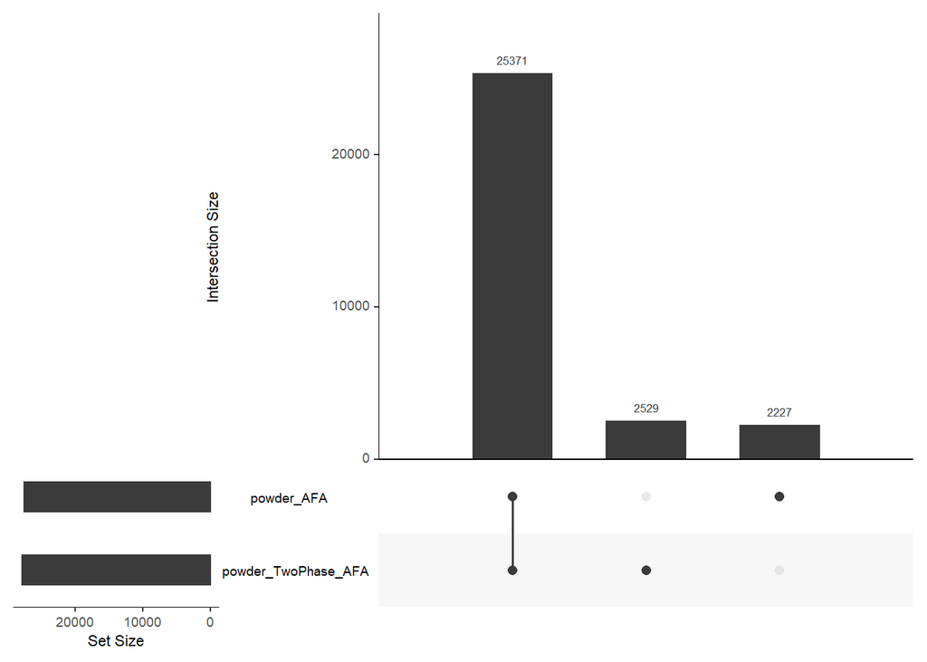

Only continue with the shared features in the following analyses.

## 5.2 FFPE: CV (contrast 1)

```
## [1] "mean: powder_AFA"
```

```
## [1] 6.805204
```

```
## [1] "mean: powder_TwoPhase_AFA"
```

```
## [1] 4.756917
```

```
##
##  Wilcoxon signed rank test with continuity correction
##
## data:  cv_a and cv_b
## V = 104442117, p-value < 2.2e-16
## alternative hypothesis: true location shift is not equal to 0
```

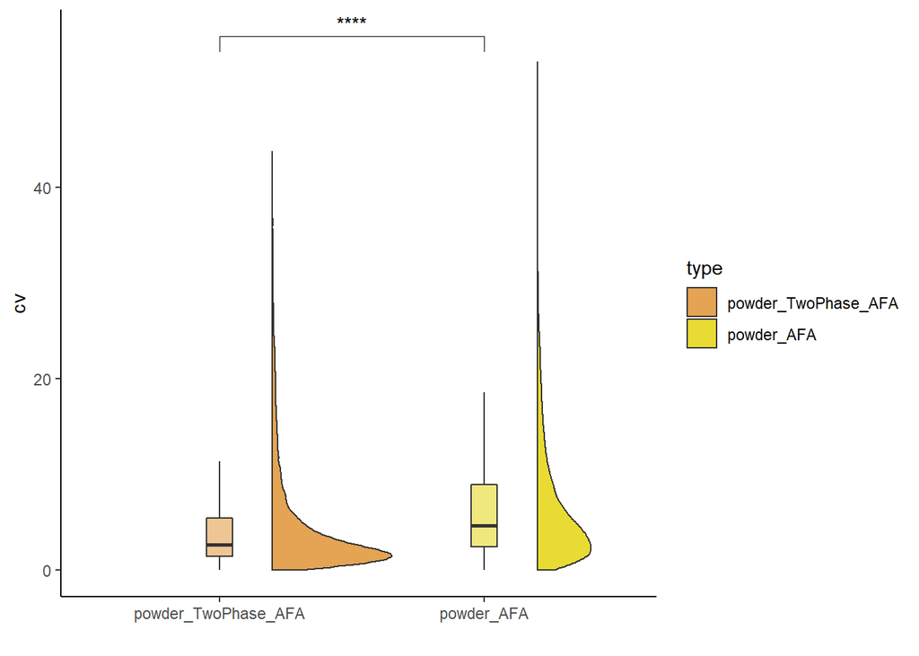

## 5.3 FFPE: Differential expression analysis (contrast 1)

```
## [1] "## contrast: powder_AFA - powder_TwoPhase_AFA"
```

|  | logFC | AveExpr | t | P.Value | adj.P.Val | B |
| --- | --- | --- | --- | --- | --- | --- |
| AAAAAAAAAAAATGTEAGPGTAGGSENGSEVAAQPAGLSGPAEVGPGAVGER | -0.614933863 | 10.033501 | -0.960174656 | 4.217169e-01 | 0.81612236 | -5.55836711 |
| AAAAAAAAVPSAGPAGPAPTSAAGR | 0.375713199 | 11.410261 | 0.837340886 | 4.170262e-01 | 0.81353440 | -6.24725605 |
| AAAAAAAGDSDSWDADAFSVEDPVRK | -0.181698966 | 8.680188 | -0.274441351 | 7.938383e-01 | 0.95964000 | -6.03396280 |
| AAAAAAALQAK | 3.283986904 | 11.910335 | 4.797374281 | 6.409352e-04 | 0.07009123 | -0.02422139 |
| AAAAAAALQAKSDEK | -0.097275695 | 9.515813 | -0.203521086 | 8.420150e-01 | 0.96861937 | -6.58573524 |
| AAAAAAGAASGLPGPVAQGLK | 0.291750495 | 12.941212 | 1.385885062 | 1.883226e-01 | 0.66499887 | -5.66166704 |
| AAAAAAGAGPEMVR | -0.355646713 | 11.643683 | -0.847079487 | 4.117647e-01 | 0.81147130 | -6.23904304 |
| AAAAAAGSGTPR | -0.167551005 | 9.172683 | -0.371365151 | 7.166059e-01 | 0.93784215 | -6.42590033 |
| AAAAAATAPPSPGPAQPGPR | 0.395973785 | 10.289700 | 1.268417537 | 2.261558e-01 | 0.69554662 | -5.80675135 |
| AAAAAEQQQFYLLLGNLLSPDNVVR | -0.327604697 | 12.995546 | -0.808961306 | 4.350177e-01 | 0.82308572 | -6.26804111 |

[output cut: 490 more lines]

## 5.4 FFPE: Association to physico-chemical parameters (contrast 1)

Take the t-values and plot against the GRAVY-Score and Isoelectric point (for shared features).

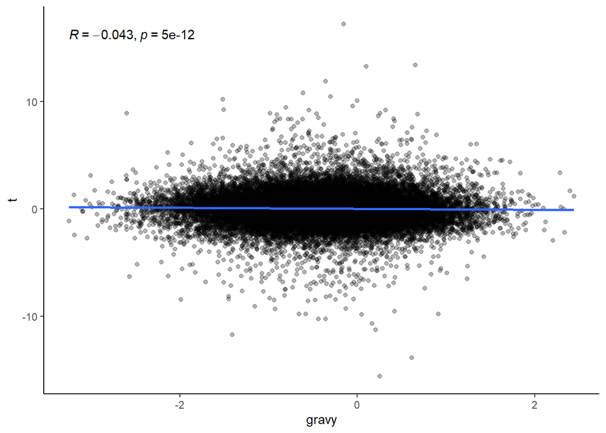

```
##
##  Spearman's rank correlation rho
##
## data:  gravy and t
## S = 2.8398e+12, p-value = 4.954e-12
## alternative hypothesis: true rho is not equal to 0
## sample estimates:
##         rho
## -0.04334416
```

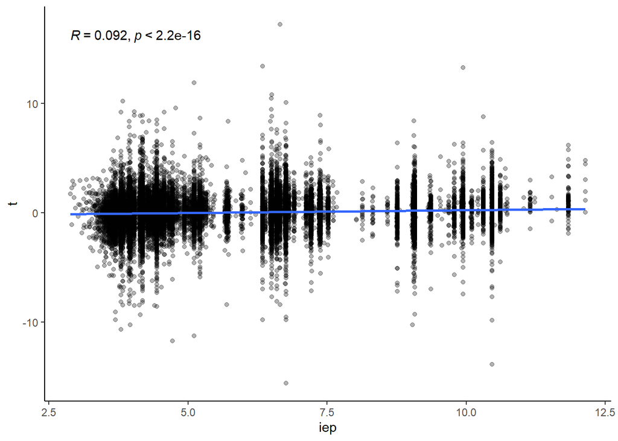

```
##
##  Spearman's rank correlation rho
##
## data:  iep and t
## S = 2.4722e+12, p-value < 2.2e-16
## alternative hypothesis: true rho is not equal to 0
## sample estimates:
##        rho
## 0.09169794
```

Create violin plots for shared/unique features.

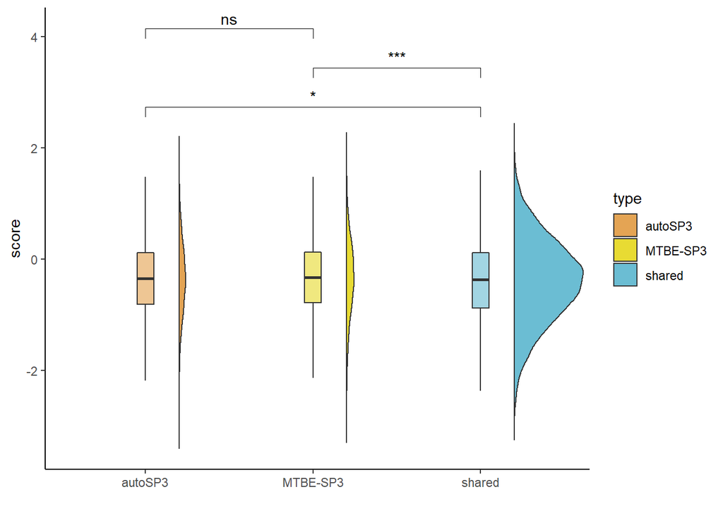

```r
## gravy
feat <- read.table(file = "peptides_unique_features_ffpe_contrast1_powder.txt",
    header = TRUE)
gravy_other <- lapply(feat[, 1], function(aa) calculateGravyScore(aa))
feat <- read.table(file = "peptides_unique_features_ffpe_contrast1_TwoPhase.txt",
    header = TRUE)
gravy_tp <- lapply(feat[, 1], function(aa) calculateGravyScore(aa))

## create df
df <- data.frame(rbind(
    cbind(unlist(gravy), "shared"),
    cbind(unlist(gravy_other), "autoSP3"),
    cbind(unlist(gravy_tp), "MTBE-SP3")))
colnames(df) <- c("score", "type")
df$score <- as.numeric(df$score)
df$type <- factor(df$type, levels = c("autoSP3", "MTBE-SP3", "shared"))
comparisons <- list( c("autoSP3", "shared"), c("MTBE-SP3", "shared"),
    c("autoSP3", "MTBE-SP3"))

plot_violin_barplot(df = df, x = "type", y = "score", fill = "type",
    comparisons = comparisons, file = "peptide_violin_gravy_FFPE_1.pdf",
    method = "wilcox.test", paired = FALSE)
```

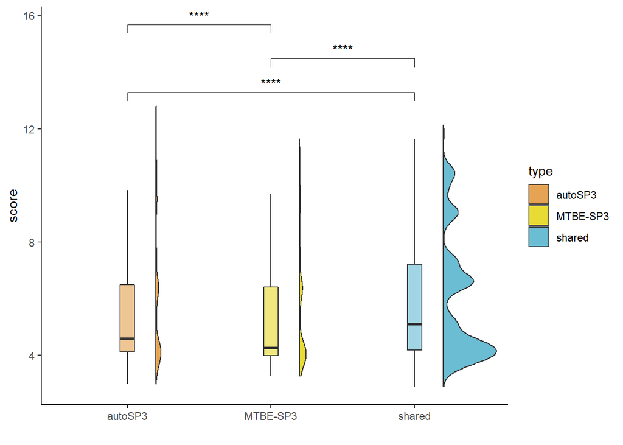

```r
## iep
feat <- read.table(file = "peptides_unique_features_ffpe_contrast1_powder.txt",
    header = TRUE)
iep_other <- lapply(feat[, 1], function(aa) calculateIsoelectricPoint(aa))
feat <- read.table(file = "peptides_unique_features_ffpe_contrast1_TwoPhase.txt",
    header = TRUE)
iep_tp <- lapply(feat[, 1], function(aa) calculateIsoelectricPoint(aa))

## create df
df <- data.frame(rbind(
    cbind(unlist(iep), "shared"),
    cbind(unlist(iep_other), "autoSP3"),
    cbind(unlist(iep_tp), "MTBE-SP3")))
colnames(df) <- c("score", "type")
df$score <- as.numeric(df$score)
df$type <- factor(df$type, levels = c("autoSP3", "MTBE-SP3", "shared"))
comparisons <- list( c("autoSP3", "shared"), c("MTBE-SP3", "shared"),
    c("autoSP3", "MTBE-SP3"))

plot_violin_barplot(df = df, x = "type", y = "score", fill = "type",
    comparisons = comparisons, file = "peptide_violin_iep_FFPE_1.pdf",
    method = "wilcox.test", paired = FALSE)
```

## 5.5 FFPE: Overlap, uniqueness of features (contrast 2)

The plot shows the interaction of sets between different variables depending on their presence. The dots in the UpSet plot specify if the criteria for presence are fulfilled: Presence is defined by a feature being measured in at least one sample of a set.

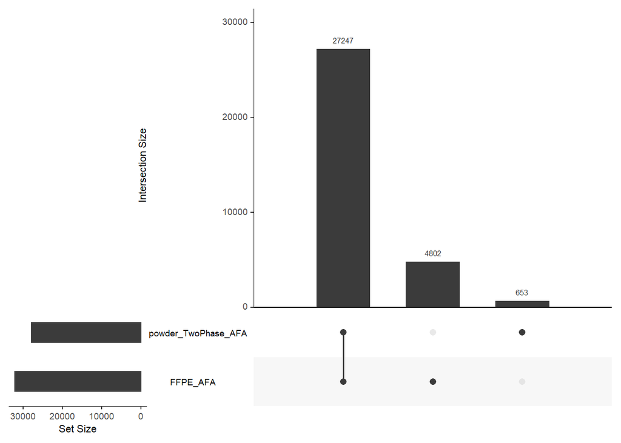

Only continue with the shared features in the following analyses.

## 5.6 FFPE: CV (contrast 2)

```
## [1] "mean: FFPE_AFA"
```

```
## [1] 5.554668
```

```
## [1] "mean: powder_TwoPhase_AFA"
```

```
## [1] 4.924581
```

```
##
##  Wilcoxon signed rank test with continuity correction
##
## data:  cv_a and cv_b
## V = 147967073, p-value < 2.2e-16
## alternative hypothesis: true location shift is not equal to 0
```

[figure not shown]

## 5.7 FFPE: Differential expression analysis (contrast 2)

```
## [1] "## contrast: FFPE_AFA - powder_TwoPhase_AFA"
```

|  | logFC | AveExpr | t | P.Value | adj.P.Val | B |
| --- | --- | --- | --- | --- | --- | --- |
| AAAAAAAAVPSAGPAGPAPTSAAGR | -1.279510945 | 11.410261 | -3.439168851 | 4.202281e-03 | 0.0359270631 | -2.29633685 |
| AAAAAAAGDSDSWDADAFSVEDPVRK | 0.007113387 | 8.680188 | 0.013590440 | 9.896399e-01 | 0.9941643288 | -6.28362975 |
| AAAAAAALQAK | 4.180156730 | 11.910335 | 9.460201180 | 1.889922e-06 | 0.0006436838 | 5.51504023 |
| AAAAAAALQAKSDEK | -1.880400904 | 9.515813 | -4.654998427 | 5.038200e-04 | 0.0124584533 | -0.12878387 |
| AAAAAAGAASGLPGPVAQGLK | 0.043300395 | 12.941212 | 0.248068214 | 8.078273e-01 | 0.8842193261 | -6.74189879 |
| AAAAAAGAGPEMVR | 1.327345626 | 11.643683 | 3.812879124 | 2.032269e-03 | 0.0244311613 | -1.57875988 |
| AAAAAAGSGTPR | 0.282954066 | 9.172683 | 0.845646204 | 4.137011e-01 | 0.5815709517 | -6.40381240 |
| AAAAAATAPPSPGPAQPGPR | -1.247803436 | 10.289700 | -4.820650303 | 3.035710e-04 | 0.0097538216 | 0.31862760 |
| AAAAAEQQQFYLLLGNLLSPDNVVR | -0.665806636 | 12.995546 | -1.898432313 | 8.311103e-02 | 0.2057724843 | -5.05523925 |
| AAAAAGAGSGPWAAQEK | 0.173990800 | 9.995696 | 0.496612101 | 6.281116e-01 | 0.7585726120 | -6.62545411 |

[output cut: 490 more lines]

## 5.8 FFPE: Association to physico-chemical parameters (contrast 2)

Take the t-values and plot against the GRAVY-Score and Isoelectric point (for shared features).

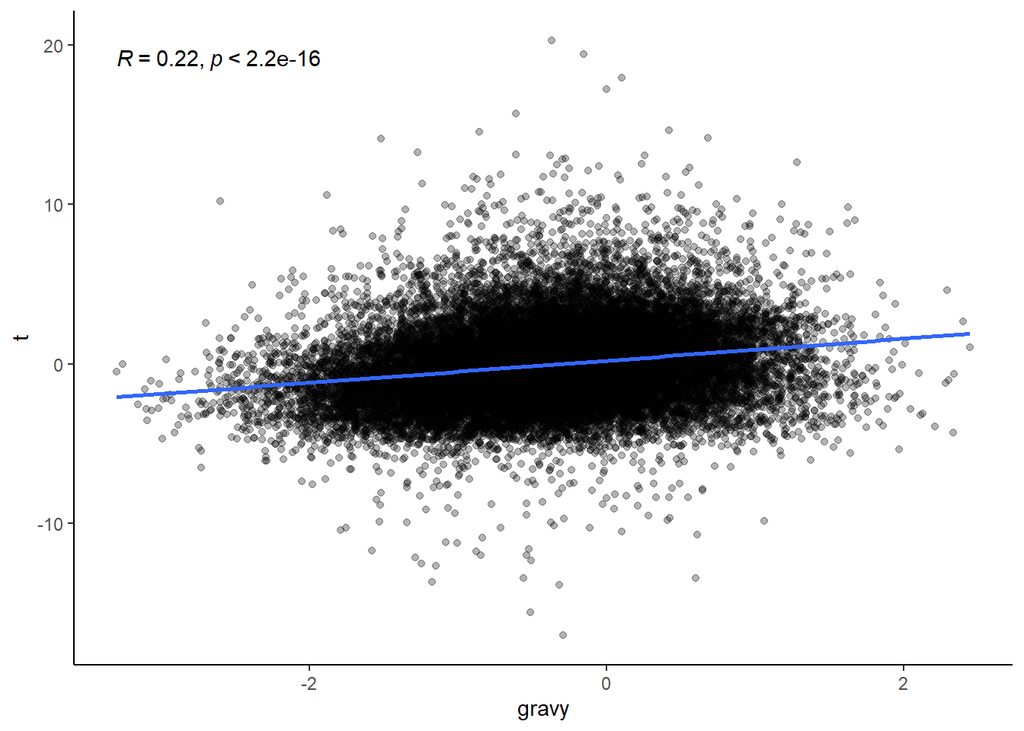

```
##
##  Spearman's rank correlation rho
##
## data:  gravy and t
## S = 2.6147e+12, p-value < 2.2e-16
## alternative hypothesis: true rho is not equal to 0
## sample estimates:
##       rho
## 0.2244422
```

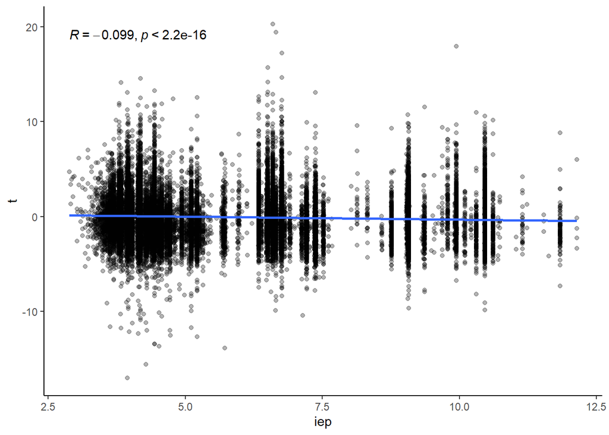

```
##
##  Spearman's rank correlation rho
##
## data:  iep and t
## S = 3.7064e+12, p-value < 2.2e-16
## alternative hypothesis: true rho is not equal to 0
## sample estimates:
##         rho
## -0.09937823
```

Create violin plots for shared/unique features.

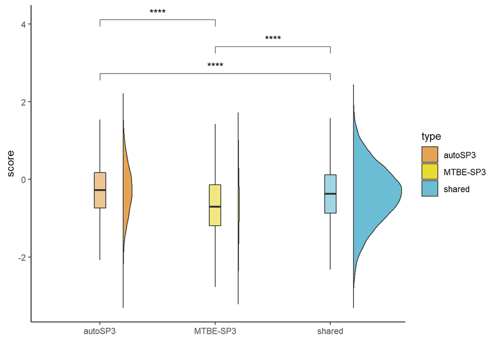

```r
## gravy
feat <- read.table(file = "peptides_unique_features_ffpe_contrast2_FFPE.txt",
    header = TRUE)
gravy_other <- lapply(feat[, 1], function(aa) calculateGravyScore(aa))
feat <- read.table(file = "peptides_unique_features_ffpe_contrast2_powder_TwoPhase.txt",
    header = TRUE)
gravy_tp <- lapply(feat[, 1], function(aa) calculateGravyScore(aa))

## create df
df <- data.frame(rbind(
    cbind(unlist(gravy), "shared"),
    cbind(unlist(gravy_other), "autoSP3"),
    cbind(unlist(gravy_tp), "MTBE-SP3")))
colnames(df) <- c("score", "type")
df$score <- as.numeric(df$score)
df$type <- factor(df$type, levels = c("autoSP3", "MTBE-SP3", "shared"))
comparisons <- list( c("autoSP3", "shared"), c("MTBE-SP3", "shared"),
    c("autoSP3", "MTBE-SP3"))

plot_violin_barplot(df = df, x = "type", y = "score", fill = "type",
    comparisons = comparisons, file = "peptide_violin_gravy_FFPE_2.pdf",
    method = "wilcox.test", paired = FALSE)
```

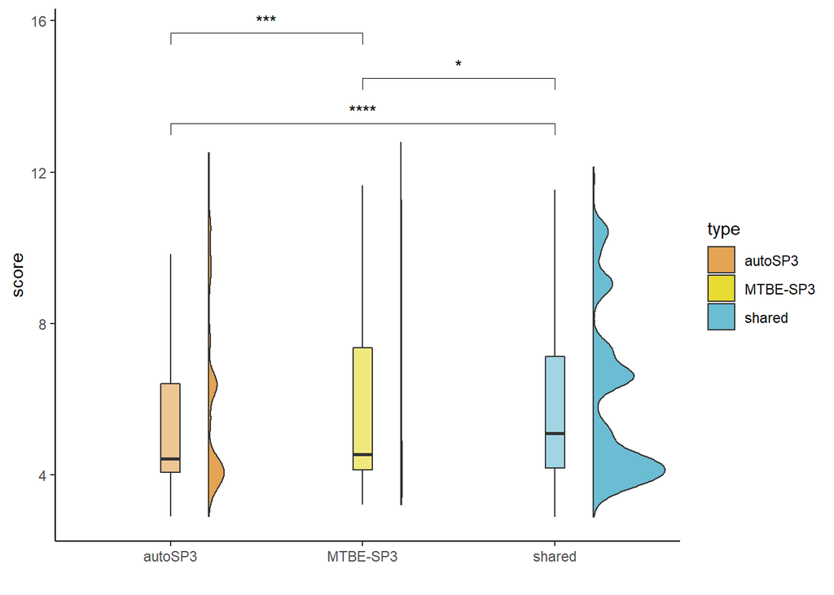

```r
## iep
feat <- read.table(file = "peptides_unique_features_ffpe_contrast2_FFPE.txt",
    header = TRUE)
iep_other <- lapply(feat[, 1], function(aa) calculateIsoelectricPoint(aa))
feat <- read.table(file = "peptides_unique_features_ffpe_contrast2_powder_TwoPhase.txt",
    header = TRUE)
iep_tp <- lapply(feat[, 1], function(aa) calculateIsoelectricPoint(aa))

## create df
df <- data.frame(rbind(
    cbind(unlist(iep), "shared"),
    cbind(unlist(iep_other), "autoSP3"),
    cbind(unlist(iep_tp), "MTBE-SP3")))
colnames(df) <- c("score", "type")
df$score <- as.numeric(df$score)
df$type <- factor(df$type, levels = c("autoSP3", "MTBE-SP3", "shared"))
comparisons <- list( c("autoSP3", "shared"), c("MTBE-SP3", "shared"),
    c("autoSP3", "MTBE-SP3"))

plot_violin_barplot(df = df, x = "type", y = "score", fill = "type",
    comparisons = comparisons, file = "peptide_violin_iep_FFPE_2.pdf",
    method = "wilcox.test", paired = FALSE)
```